# Risky Visual Search - Exploratory Analysis

Dave Braun

December 19 2022

This document was last updated at 2022-12-19 17:34:45.

## The story thus far

Ran an overall model looking at the impact of framing while controlling for many other variables. The reversed reflection effect remains significant. Looked only at the timing controlled condition to assess need for cognition. Found a really interesting crossover interaction such that the reversed reflection effect is only present for those high in need for cognition.

```r
d <- read.csv('../../data/main_timing.csv')
N <- length(unique(d$subject))
head(d)
```

|  | subject | trial | magnitude | direction | n_stimuli | n_stimuli_lag | present_or_absent | delay | choice_rt | search_rt | error | ssd |
| --- | --- | --- | --- | --- | --- | --- | --- | --- | --- | --- | --- | --- |
| 1 | 07iuiut1t9rh | 7 | Moderate | Easier than Reference | 4 | 32 | present | Not Enforced | 1001 | 846 | 0 | 0 |
| 2 | 07iuiut1t9rh | 9 | Moderate | Harder than Reference | 39 | 32 | absent | Not Enforced | 969 | 6181 | 0 | 1 |
| 3 | 07iuiut1t9rh | 10 | Moderate | Easier than Reference | 4 | 39 | present | Not Enforced | 891 | 829 | 0 | 0 |
| 4 | 07iuiut1t9rh | 11 | Extreme | Easier than Reference | 18 | 4 | present | Not Enforced | 808 | 1358 | 0 | 0 |
| 5 | 07iuiut1t9rh | 12 | Extreme | Harder than Reference | 32 | 18 | present | Not Enforced | 877 | 1395 | 0 | 0 |
| 6 | 07iuiut1t9rh | 13 | Moderate | Easier than Reference | 4 | 32 | absent | Not Enforced | 701 | 1336 | 0 | 0 |

```r
e2_demo <- read.csv('../../../exp2/data/exp2_demo.csv')
```

Initial sample size is 100.

```r
d <- d %>%
  mutate(direction = recode(direction, `Easier than Reference` = 'Easier',
                          `Harder than Reference` = 'Harder'))
```

### Preprocess NFC scale

```r
## preprocess NFC scale

reverse_items <- c(3,4,5,7,8,9,12,16,17)
response_code <- data.frame(response = c('neutral', 'somewhat_agree', 'somewhat_disagree', 'strongly_agree', 'strongly_disagree', ''), numeric = c(3, 4, 2, 5, 1, NA))
survey <- e2_demo %>%
  gather(question, response, cog_effort_q1:cog_effort_q18) %>%
  select(subject, question, response) %>%
  inner_join(response_code)
reverse_items <- c(3,4,5,7,8,9,12,16,17)
response_code <- data.frame(response = c('neutral', 'somewhat_agree', 'somewhat_disagree', 'strongly_agree', 'strongly_disagree', ''), numeric = c(3, 4, 2, 5, 1, NA))
survey <- e2_demo %>%
  gather(question, response, cog_effort_q1:cog_effort_q18) %>%
  select(subject, question, response) %>%
  inner_join(response_code)
parse_question <- function(q) {
  return(as.numeric(sub('.', '', unlist(strsplit(q, split='_'))[3])))
}

survey <- survey %>%
  mutate(question = Vectorize(parse_question)(question)) %>%
  mutate(numeric_final = ifelse(question %in% reverse_items, 6-numeric, numeric)) %>%
  arrange(subject) %>%
  select(-response, -numeric) %>%
  rename(response = numeric_final)

d <- survey %>%
    filter(!is.na(response)) %>%
    group_by(subject) %>%
    summarize(cog_need = mean(response)) %>%
    right_join(d)
```

### Compute performance metric

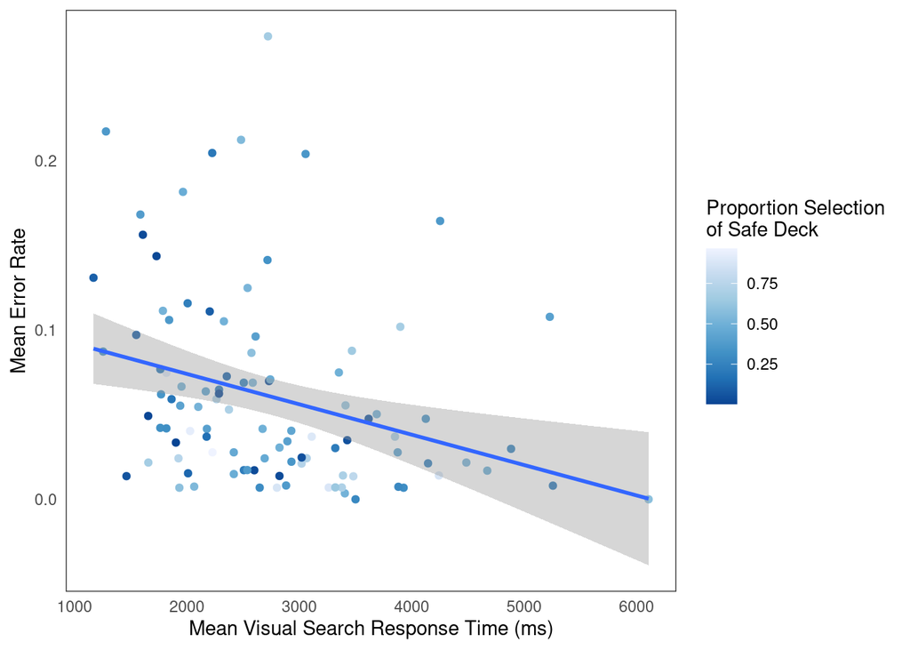

```r
sp <- d %>%
    group_by(subject) %>%
    summarize(ssd = mean(ssd), search_rt = mean(search_rt), error = mean(error))
sp %>%
    ggplot(aes(x = search_rt, y = error, label = subject)) +
    geom_point(aes(color = ssd)) +
    geom_smooth(method='lm') +
    scale_color_distiller() +
    labs(
        x = 'Mean Visual Search Response Time (ms)',
        y = 'Mean Error Rate',
        color = 'Proportion Selection \nof Safe Deck'
    ) +
    theme_bw() +
    theme(axis.ticks = element_blank(),
          panel.grid = element_blank())
```

**Compute correlation**

```r
cor.test(sp$search_rt, sp$error)
```

```
##
##  Pearson's product-moment correlation
##
## data:  sp$search_rt and sp$error
## t = -3.1572, df = 98, p-value = 0.002117
## alternative hypothesis: true correlation is not equal to 0
## 95 percent confidence interval:
##  -0.4720888 -0.1142454
## sample estimates:
##        cor
## -0.3038452
```

```r
sp$search_rt_c <- scale(sp$search_rt)[,1]
sp$error_c <- scale(sp$error)[,1]

min(sp$search_rt_c)
```

```
## [1] -1.657087
```

```r
min(sp$error_c)
```

```
## [1] -1.07381
```

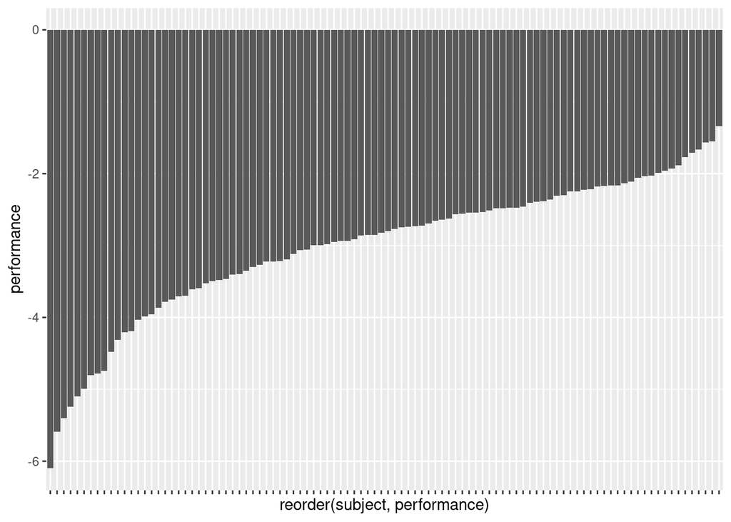

```r
sp <- sp %>%
    mutate(performance = sqrt((-2 - error_c)^2 + (-2 - search_rt_c)^2))
sp$performance <- -sp$performance

sp %>%
    ggplot(aes(x = reorder(subject, performance), y = performance)) +
    geom_bar(stat = 'identity') +
    theme(axis.text.x = element_blank())
```

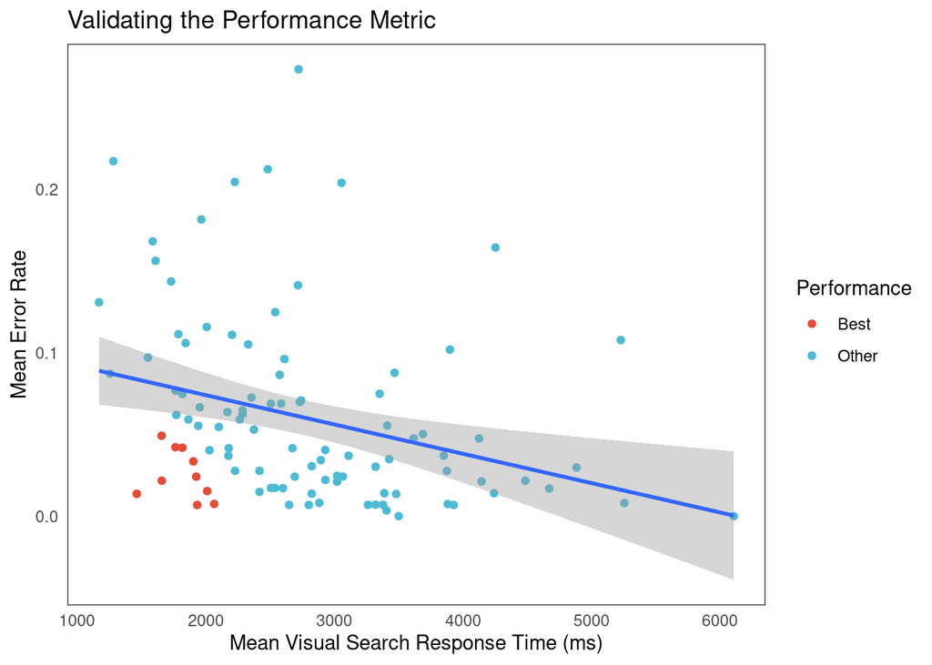

```r
best <- sp %>%
    arrange(-performance) %>%
    select(subject, performance) %>%
    slice_head(n = 10) %>%
    select(subject)
best <- best$subject

sp$best <- ifelse(sp$subject %in% best, 'Best', 'Other')

sp %>%
    ggplot(aes(x = search_rt, y = error, label = subject)) +
    geom_point(aes(color = best)) +
    geom_smooth(method='lm') +
    scale_color_npg() +
    labs(
        title = 'Validating the Performance Metric',
        x = 'Mean Visual Search Response Time (ms)',
        y = 'Mean Error Rate',
        color = 'Performance'
    ) +
    theme_bw() +
    theme(axis.ticks = element_blank(),
          panel.grid = element_blank())
```

```r
sp$performance <- scale(sp$performance)

d <- sp %>%
    select(subject, performance) %>%
    inner_join(d)
```

## Include performance into choice model

```r
library(lme4)
library(car)
d$delay_e <- ifelse(d$delay == 'Enforced', -0.5, 0.5)
d$direction_e <- ifelse(d$direction == 'Easier', -0.5, 0.5)
d$n_stimuli_lag_c <- scale(d$n_stimuli_lag)[,1]
d$magnitude_e <- ifelse(d$magnitude == 'Moderate', -0.5, 0.5)
d$trial_c <- ifelse(d$delay == 'Enforced',
                    scale(d[d$delay=='Enforced',]$trial)[,1],
                    scale(d[d$delay == 'Not Enforced',]$trial)[,1])
d <- d[!is.na(d$n_stimuli_lag),]
#
# m1 <- glmer(ssd ~ direction_e * delay_e * performance +
#                 (1 + direction_e * delay_e | subject),
#             data = d, family = binomial(link = 'logit'),
#             control = glmerControl(optimizer = 'bobyqa'),
#             nAGQ = 1)
#
# m2 <- glmer(ssd ~ direction_e * delay_e * performance +
#                 (1 | subject) +
#                 (0 + direction_e * delay_e | subject),
#             data = d, family = binomial(link = 'logit'),
#             control = glmerControl(optimizer = 'bobyqa'),
#             nAGQ = 1)
#
# m3 <- glmer(ssd ~ direction_e * delay_e * performance +
#                 (1 | subject) +
#                 (0 + direction_e + delay_e | subject) +
#                 (0 + direction_e:delay_e | subject),
#             data = d, family = binomial(link = 'logit'),
#             control = glmerControl(optimizer = 'bobyqa'),
#             nAGQ = 1)
#
# m4 <- glmer(ssd ~ direction_e * delay_e * performance +
#                 (1 | subject) +
#                 (0 + direction_e + delay_e | subject),
#             data = d, family = binomial(link = 'logit'),
#             control = glmerControl(optimizer = 'bobyqa'),
#             nAGQ = 1)
#
# m5 <- glmer(ssd ~ direction_e * delay_e * performance +
#                 (1 | subject) +
#                 (0 + direction_e | subject) +
#                 (0 + delay_e | subject),
#             data = d, family = binomial(link = 'logit'),
#             control = glmerControl(optimizer = 'bobyqa'),
#             nAGQ = 1)
#
# m6 <- glmer(ssd ~ direction_e +
#                 trial_c +
#                  magnitude_e +
#                 delay_e +
#                 n_stimuli_lag_c +
#                 performance +
#                 (1 | subject) +
#                 (0 + magnitude_e | subject) +
#                 (0 + direction_e | subject) +
#                 (0 + trial_c | subject) +
#                 (0 + n_stimuli_lag_c | subject),
#             data = d, family = binomial(link = 'logit'),
#             control = glmerControl(optimizer = 'bobyqa'),
#             nAGQ = 1)

m7 <- glmer(ssd ~ direction_e +
                trial_c +
                 magnitude_e +
                delay_e +
                n_stimuli_lag_c +
                performance +
                (1 | subject) +
                (0 + direction_e | subject) +
                (0 + trial_c | subject) +
                (0 + magnitude_e | subject),
            data = d, family = binomial(link = 'logit'),
            control = glmerControl(optimizer = 'bobyqa'),
            nAGQ = 1)
# anova(m6, m7)

#
# m7 <- glmer(ssd ~ direction_e * delay_e * performance +
#                 (1 | subject),
#             data = d, family = binomial(link = 'logit'),
#             control = glmerControl(optimizer = 'bobyqa'),
#             nAGQ = 1)
#
# anova(m7, m6)

mm <- m7
```

```r
m_reduced <- glmer(ssd ~ direction_e +
                       #magnitude_e +
                       n_stimuli_lag_c +
                       trial_c +
                       delay_e +
                       performance +
                (1 | subject) +
                (0 + magnitude_e | subject) +
                (0 + trial_c | subject) +
                (0 + direction_e | subject),
            data = d, family = binomial(link = 'logit'),
            control = glmerControl(optimizer = 'bobyqa'),
            nAGQ = 1)

anova(mm, m_reduced)
```

|  | npar | AIC | BIC | logLik | deviance | Chisq | Df | Pr(>Chisq) |
| --- | --- | --- | --- | --- | --- | --- | --- | --- |
| m_reduced | 10 | 19410.74 | 19489.54 | -9695.368 | 19390.74 | NA | NA | NA |
| mm | 11 | 19408.90 | 19495.59 | -9693.452 | 19386.90 | 3.831082 | 1 | 0.05031044 |

```r
summary(mm)
```

```
## Generalized linear mixed model fit by maximum likelihood (Laplace
##   Approximation) [glmerMod]
##  Family: binomial  ( logit )
## Formula:
## ssd ~ direction_e + trial_c + magnitude_e + delay_e + n_stimuli_lag_c +
##     performance + (1 | subject) + (0 + direction_e | subject) +
##     (0 + trial_c | subject) + (0 + magnitude_e | subject)
##    Data: d
## Control: glmerControl(optimizer = "bobyqa")
##
##      AIC      BIC   logLik deviance df.resid
##  19408.9  19495.6  -9693.5  19386.9    19525
##
## Scaled residuals:
##     Min      1Q  Median      3Q     Max
## -9.0520 -0.6199 -0.1809  0.6622 10.0518
##
## Random effects:
##  Groups    Name        Variance Std.Dev.
##  subject   (Intercept) 2.55521  1.5985
##  subject.1 direction_e 2.10948  1.4524
##  subject.2 trial_c     0.13188  0.3631
##  subject.3 magnitude_e 0.05075  0.2253
## Number of obs: 19536, groups:  subject, 100
##
## Fixed effects:
##                 Estimate Std. Error z value Pr(>|z|)
## (Intercept)     -0.57999    0.16180  -3.585 0.000338 ***
## direction_e      0.48952    0.15250   3.210 0.001328 **
## trial_c         -0.04368    0.04235  -1.032 0.302300
## magnitude_e     -0.08778    0.04375  -2.006 0.044824 *
## delay_e          0.30752    0.32795   0.938 0.348394
## n_stimuli_lag_c  0.04703    0.01866   2.521 0.011709 *
## performance     -0.09654    0.16490  -0.585 0.558232
## ---
## Signif. codes:  0 '***' 0.001 '**' 0.01 '*' 0.05 '.' 0.1 ' ' 1
##
## Correlation of Fixed Effects:
##             (Intr) drctn_ tril_c mgntd_ delay_ n_st__
## direction_e -0.001
## trial_c      0.003  0.001
## magnitude_e  0.001  0.001  0.003
## delay_e     -0.026  0.000  0.000  0.000
## n_stml_lg_c -0.001  0.047  0.003  0.051  0.002
## performance  0.006  0.000 -0.008  0.000 -0.167 -0.001
```

```r
exp(fixef(mm))
```

```
##     (Intercept)     direction_e         trial_c     magnitude_e         delay_e
##       0.5599051       1.6315281       0.9572591       0.9159651       1.3600522
## n_stimuli_lag_c     performance
##       1.0481585       0.9079720
```

```r
exp(confint(mm, method = 'Wald'))
```

```
##                     2.5 %    97.5 %
## .sig01                 NA        NA
## .sig02                 NA        NA
## .sig03                 NA        NA
## .sig04                 NA        NA
## (Intercept)     0.4077484 0.7688411
## direction_e     1.2099958 2.1999118
## trial_c         0.8810162 1.0400999
## magnitude_e     0.8406948 0.9979746
## delay_e         0.7151595 2.5864746
## n_stimuli_lag_c 1.0105193 1.0871997
## performance     0.6572224 1.2543900
```

No interactions with n_stimuli on previous trial.

I think maybe just hit this in a quick sentence saying the effects hold when accounting for individual differences in task performance. Show in an appendix if needed.

```r
library(ggExtra)
```

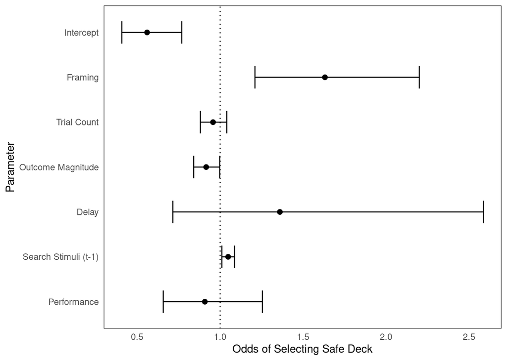

```r
ci <- exp(confint(mm, method = 'Wald'))
levels <- c('Intercept', 'Framing', 'Trial Count', 'Outcome Magnitude',
            'Delay', 'Search Stimuli (t-1)', 'Performance')

parameter <- factor(levels, levels = rev(levels))
pd <- data.frame(parameter = parameter, estimate = exp(fixef(mm)),
                 lower = ci[5:(nrow(ci)),1], upper = ci[5:(nrow(ci)),2])

pd %>%
    ggplot(aes(x = parameter, y = estimate)) +
    geom_hline(yintercept = 1, linetype = 'dotted') +
    geom_point(size = 2) +
    geom_errorbar(aes(ymin = lower, ymax = upper), width = .5) +
    coord_flip() +
    labs(
        x = 'Parameter',
        y = 'Odds of Selecting Safe Deck'
    ) +
    theme_bw() +
    theme(axis.ticks = element_blank(),
          panel.grid = element_blank())
```

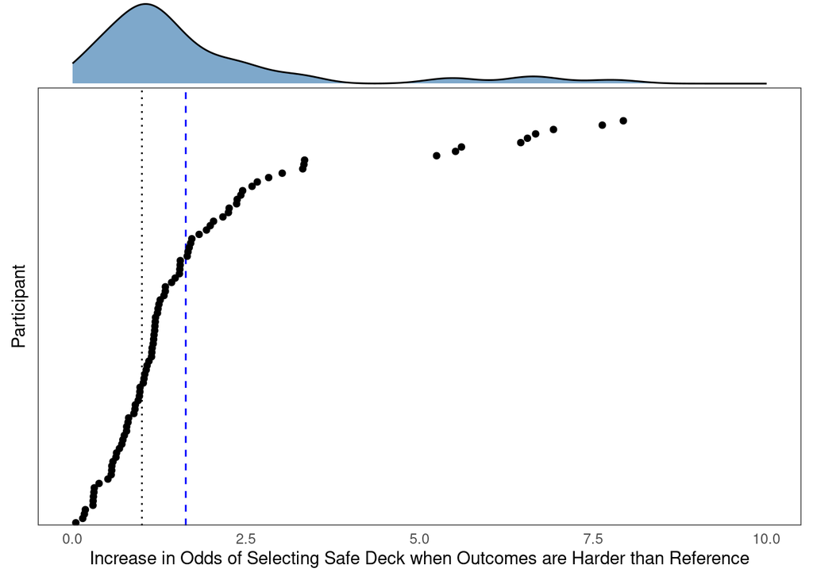

```r
r <- data.frame(mode = ranef(mm, condVar = TRUE))
r <- r[r$mode.term == 'direction_e',]
r$fixed <- fixef(mm)[2]
r$fixed_odds_ratio <- exp(r$fixed)
r$random_beta <- r$mode.condval + r$fixed
r$odds_ratio <- exp(r$random_beta)
r$sd_or <- exp(r$mode.condsd)

p1 <- r %>%
    mutate(id = 1:(nrow(.))) %>%
    ggplot(aes(x = reorder(id, odds_ratio), y = odds_ratio)) +
    geom_hline(yintercept = 1, linetype = 'dotted') +
    geom_hline(yintercept = unique(r$fixed_odds_ratio), linetype = 'dashed', color = 'blue') +
    geom_point() +
    ylim(0, 10) +
    labs(
        x = 'Participant',
        y = 'Increase in Odds of Selecting Safe Deck when Outcomes are Harder than Reference'
    ) +
    coord_flip() +
    theme_bw() +
    theme(
        panel.grid = element_blank(),
        axis.ticks = element_blank(),
        axis.text.y = element_blank())

ggMarginal(p1, margins = 'x', fill = 'steelblue', alpha = .7)
```

Honestly inspecting the estimates this way is a bit sobering. Majority of subjects seem like they cluster more around the null hypothesis.

## Incorporating need for cognition

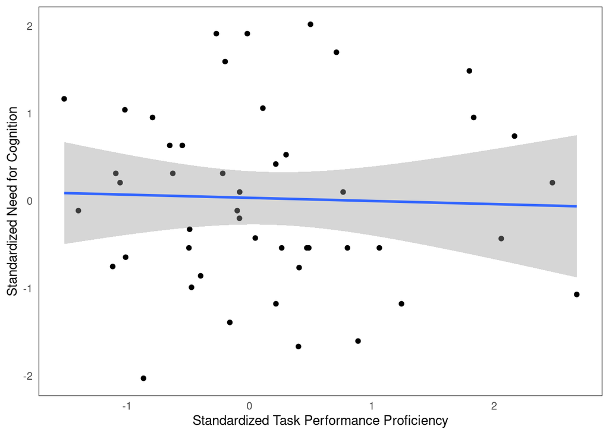

```r
e2 <- d[d$delay == 'Enforced',]
e2$cog_need_c <- scale(e2$cog_need)[,1]

e2 %>%
    group_by(subject) %>%
    summarize(cog_need = mean(cog_need_c), performance = -mean(performance)) %>%
    ggplot(aes(x = performance, y = cog_need)) +
    geom_point() +
    geom_smooth(method = 'lm') +
    labs(
        x = 'Standardized Task Performance Proficiency',
        y = 'Standardized Need for Cognition'
    ) +
    theme_bw() +
    theme(axis.ticks = element_blank(),
          panel.grid = element_blank())
```

```r
e2 <- d[d$delay == 'Enforced',]
e2$cog_need_c <- scale(e2$cog_need)[,1]

mm <- glmer(ssd ~ direction_e * cog_need_c +
                 performance +
                magnitude_e +
                trial_c +
                n_stimuli_lag_c +
                (1 | subject) +
                (0 + magnitude_e | subject) +
                (0 + trial_c | subject) +
                (0 + direction_e | subject),
            data = e2,
            family = binomial(link = 'logit'),
            control = glmerControl(optimizer = 'bobyqa'),
            nAGQ = 1)

## test direction
print('Test main effect of direction')
```

```
## [1] "Test main effect of direction"
```

```r
m_direction <- glmer(ssd ~ direction_e:cog_need_c +
                cog_need_c +
                 performance +
                magnitude_e +
                trial_c +
                n_stimuli_lag_c +
                (1 | subject) +
                (0 + magnitude_e | subject) +
                (0 + trial_c | subject) +
                (0 + direction_e | subject),
            data = e2,
            family = binomial(link = 'logit'),
            control = glmerControl(optimizer = 'bobyqa'),
            nAGQ = 1)

anova(m_direction, mm)
```

|  | npar | AIC | BIC | logLik | deviance | Chisq | Df | Pr(>Chisq) |
| --- | --- | --- | --- | --- | --- | --- | --- | --- |
| m_direction | 11 | 6683.923 | 6758.292 | -3330.962 | 6661.923 | NA | NA | NA |
| mm | 12 | 6684.183 | 6765.312 | -3330.091 | 6660.183 | 1.740495 | 1 | 0.1870762 |

```r
## test direction X cog need
print('Test two way interaction of direction and need for cognition')
```

```
## [1] "Test two way interaction of direction and need for cognition"
```

```r
m_direction_cogneed <- glmer(ssd ~ direction_e +
                cog_need_c +
                 performance +
                magnitude_e +
                trial_c +
                n_stimuli_lag_c +
                (1 | subject) +
                (0 + magnitude_e | subject) +
                (0 + trial_c | subject) +
                (0 + direction_e | subject),
            data = e2,
            family = binomial(link = 'logit'),
            control = glmerControl(optimizer = 'bobyqa'),
            nAGQ = 1)

anova(mm, m_direction_cogneed)
```

|  | npar | AIC | BIC | logLik | deviance | Chisq | Df | Pr(>Chisq) |
| --- | --- | --- | --- | --- | --- | --- | --- | --- |
| m_direction_cogneed | 11 | 6686.353 | 6760.722 | -3332.177 | 6664.353 | NA | NA | NA |
| mm | 12 | 6684.183 | 6765.312 | -3330.091 | 6660.183 | 4.170487 | 1 | 0.04113397 |

```r
summary(mm)
```

```
## Generalized linear mixed model fit by maximum likelihood (Laplace
##   Approximation) [glmerMod]
##  Family: binomial  ( logit )
## Formula: ssd ~ direction_e * cog_need_c + performance + magnitude_e +
##     trial_c + n_stimuli_lag_c + (1 | subject) + (0 + magnitude_e |
##     subject) + (0 + trial_c | subject) + (0 + direction_e | subject)
##    Data: e2
## Control: glmerControl(optimizer = "bobyqa")
##
##      AIC      BIC   logLik deviance df.resid
##   6684.2   6765.3  -3330.1   6660.2     6367
##
## Scaled residuals:
##     Min      1Q  Median      3Q     Max
## -5.3474 -0.6547 -0.1959  0.7152  7.4218
##
## Random effects:
##  Groups    Name        Variance Std.Dev.
##  subject   (Intercept) 2.43701  1.5611
##  subject.1 magnitude_e 0.04571  0.2138
##  subject.2 trial_c     0.07707  0.2776
##  subject.3 direction_e 1.56007  1.2490
## Number of obs: 6379, groups:  subject, 47
##
## Fixed effects:
##                        Estimate Std. Error z value Pr(>|z|)
## (Intercept)            -0.67316    0.23414  -2.875  0.00404 **
## direction_e             0.26348    0.19731   1.335  0.18176
## cog_need_c             -0.08442    0.22944  -0.368  0.71292
## performance            -0.01894    0.22908  -0.083  0.93412
## magnitude_e             0.02310    0.06990   0.330  0.74104
## trial_c                -0.04292    0.05253  -0.817  0.41392
## n_stimuli_lag_c         0.03698    0.03224   1.147  0.25134
## direction_e:cog_need_c  0.40538    0.19403   2.089  0.03669 *
## ---
## Signif. codes:  0 '***' 0.001 '**' 0.01 '*' 0.05 '.' 0.1 ' ' 1
##
## Correlation of Fixed Effects:
##             (Intr) drctn_ cg_nd_ prfrmn mgntd_ tril_c n_st__
## direction_e -0.001
## cog_need_c  -0.033 -0.002
## performance  0.157  0.000 -0.035
## magnitude_e  0.000  0.001 -0.001  0.001
## trial_c      0.004  0.005  0.000 -0.002  0.006
## n_stml_lg_c -0.002  0.067  0.001  0.000  0.049  0.006
## drctn_:cg__ -0.003 -0.011  0.000  0.001  0.001 -0.003  0.011
```

```r
exp(fixef(mm))
```

```
##            (Intercept)            direction_e             cog_need_c
##              0.5100964              1.3014559              0.9190445
##            performance            magnitude_e                trial_c
##              0.9812431              1.0233689              0.9579896
##        n_stimuli_lag_c direction_e:cog_need_c
##              1.0376715              1.4998756
```

```r
exp(confint(mm, method = 'Wald'))
```

```
##                            2.5 %    97.5 %
## .sig01                        NA        NA
## .sig02                        NA        NA
## .sig03                        NA        NA
## .sig04                        NA        NA
## (Intercept)            0.3223693 0.8071437
## direction_e            0.8840477 1.9159458
## cog_need_c             0.5861878 1.4409080
## performance            0.6263014 1.5373399
## magnitude_e            0.8923491 1.1736259
## trial_c                0.8642636 1.0618799
## n_stimuli_lag_c        0.9741358 1.1053512
## direction_e:cog_need_c 1.0253986 2.1939046
```

### Following up on direction x cog need

**Observed data**

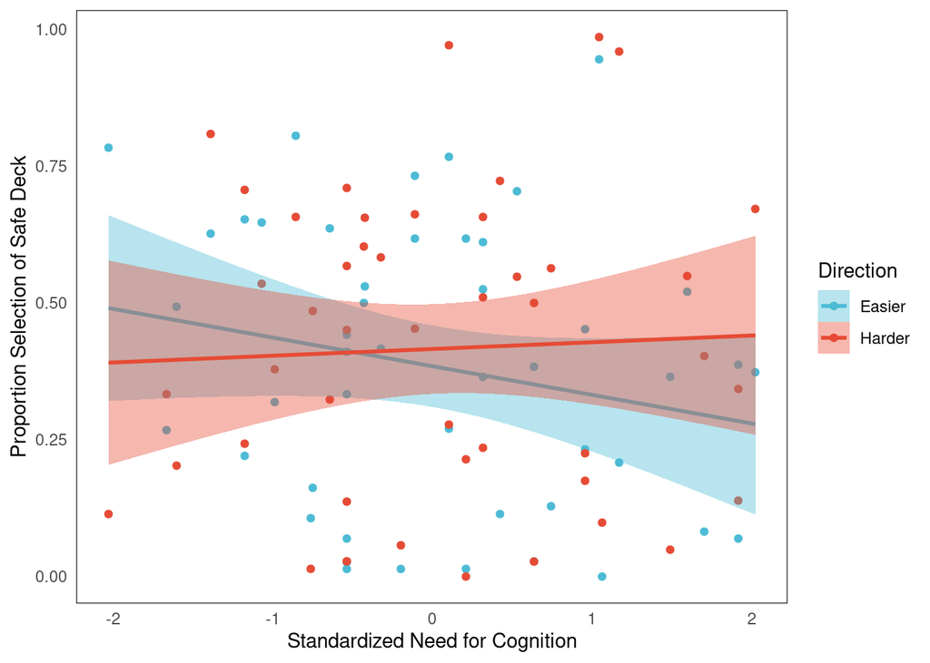

```r
npg_blue <- pal_npg('nrc')(2)[2]
npg_red <- pal_npg('nrc')(2)[1]

e2 %>%
    group_by(subject, direction) %>%
    summarize(ssd = mean(ssd), cog_need = mean(cog_need_c)) %>%
    ggplot(aes(x = cog_need, y = ssd)) +
    geom_point(aes(color = direction)) +
    geom_smooth(method = 'lm', aes(color = direction, fill = direction)) +
    labs(
        x = 'Standardized Need for Cognition',
        y = 'Proportion Selection of Safe Deck',
        color = 'Direction',
        fill = 'Direction'
    ) +
    scale_color_manual(values = c(`Easier` = npg_blue, `Harder` = npg_red)) +
    scale_fill_manual(values = c(`Easier` = npg_blue, `Harder` = npg_red)) +
    theme_bw() +
    theme(axis.ticks = element_blank(),
          panel.grid = element_blank(),
          strip.background = element_rect(color = 'black', fill = 'white'))
```

Can frame this as like high NFC people have more of an absence of aversion for the reference level and are more willing to accept the risk, as opposed to being more motivated to obtain the easiest outcome.

**Inference**

```r
print('Effect of NFC for easier than reference')
```

```
## [1] "Effect of NFC for easier than reference"
```

```r
e2$is_easier <- ifelse(e2$direction == 'Easier', 0, 1)

m1 <- glmer(ssd ~ is_easier * cog_need_c +
                 performance +
                magnitude_e +
                trial_c +
                n_stimuli_lag_c +
                (1 | subject) +
                (0 + magnitude_e | subject) +
                (0 + trial_c | subject) +
                (0 + direction_e | subject),
            data = e2,
            family = binomial(link = 'logit'),
            control = glmerControl(optimizer = 'bobyqa'),
            nAGQ = 1)

m_contrast <- glmer(ssd ~ is_easier  +
                is_easier:cog_need_c +
                 performance +
                magnitude_e +
                trial_c +
                n_stimuli_lag_c +
                (1 | subject) +
                (0 + magnitude_e | subject) +
                (0 + trial_c | subject) +
                (0 + direction_e | subject),
            data = e2,
            family = binomial(link = 'logit'),
            control = glmerControl(optimizer = 'bobyqa'),
            nAGQ = 1)
anova(m1, m_contrast)
```

|  | npar | AIC | BIC | logLik | deviance | Chisq | Df | Pr(>Chisq) |
| --- | --- | --- | --- | --- | --- | --- | --- | --- |
| m_contrast | 11 | 6683.494 | 6757.862 | -3330.747 | 6661.494 | NA | NA | NA |
| m1 | 12 | 6684.183 | 6765.312 | -3330.091 | 6660.183 | 1.311291 | 1 | 0.2521611 |

```r
exp(fixef(m1))
```

```
##          (Intercept)            is_easier           cog_need_c
##            0.4471327            1.3014548            0.7504226
##          performance          magnitude_e              trial_c
##            0.9812403            1.0233692            0.9579895
##      n_stimuli_lag_c is_easier:cog_need_c
##            1.0376715            1.4998851
```

```r
exp(confint(m1, method = 'Wald'))
```

```
##                          2.5 %    97.5 %
## .sig01                      NA        NA
## .sig02                      NA        NA
## .sig03                      NA        NA
## .sig04                      NA        NA
## (Intercept)          0.2717212 0.7357825
## is_easier            0.8840303 1.9159804
## cog_need_c           0.4605237 1.2228124
## performance          0.6262916 1.5373549
## magnitude_e          0.8923488 1.1736270
## trial_c              0.8642634 1.0618799
## n_stimuli_lag_c      0.9741357 1.1053512
## is_easier:cog_need_c 1.0253851 2.1939613
```

```r
print('Effect of NFC for harder than reference')
```

```
## [1] "Effect of NFC for harder than reference"
```

```r
e2$is_harder <- ifelse(e2$direction == 'Harder', 0, 1)

m1 <- glmer(ssd ~ is_harder * cog_need_c +
                 performance +
                magnitude_e +
                trial_c +
                n_stimuli_lag_c +
                (1 | subject) +
                (0 + magnitude_e | subject) +
                (0 + trial_c | subject) +
                (0 + direction_e | subject),
            data = e2,
            family = binomial(link = 'logit'),
            control = glmerControl(optimizer = 'bobyqa'),
            nAGQ = 1)

m_contrast <- glmer(ssd ~ is_easier  +
                is_harder:cog_need_c +
                 performance +
                magnitude_e +
                trial_c +
                n_stimuli_lag_c +
                (1 | subject) +
                (0 + magnitude_e | subject) +
                (0 + trial_c | subject) +
                (0 + direction_e | subject),
            data = e2,
            family = binomial(link = 'logit'),
            control = glmerControl(optimizer = 'bobyqa'),
            nAGQ = 1)
anova(m1, m_contrast)
```

|  | npar | AIC | BIC | logLik | deviance | Chisq | Df | Pr(>Chisq) |
| --- | --- | --- | --- | --- | --- | --- | --- | --- |
| m_contrast | 11 | 6682.408 | 6756.776 | -3330.204 | 6660.408 | NA | NA | NA |
| m1 | 12 | 6684.183 | 6765.312 | -3330.091 | 6660.183 | 0.224844 | 1 | 0.6353736 |

```r
exp(fixef(m1))
```

```
##          (Intercept)            is_harder           cog_need_c
##            0.5819245            0.7683714            1.1255431
##          performance          magnitude_e              trial_c
##            0.9812395            1.0233690            0.9579898
##      n_stimuli_lag_c is_harder:cog_need_c
##            1.0376715            0.6667224
```

```r
exp(confint(m1, method = 'Wald'))
```

```
##                          2.5 %    97.5 %
## .sig01                      NA        NA
## .sig02                      NA        NA
## .sig03                      NA        NA
## .sig04                      NA        NA
## (Intercept)          0.3537010 0.9574079
## is_harder            0.5219228 1.1311915
## cog_need_c           0.6907710 1.8339613
## performance          0.6262930 1.5373488
## magnitude_e          0.8923483 1.1736270
## trial_c              0.8642634 1.0618804
## n_stimuli_lag_c      0.9741358 1.1053512
## is_harder:cog_need_c 0.4557983 0.9752531
```

```r
print('Effect of framing for low NFC')
```

```
## [1] "Effect of framing for low NFC"
```

```r
e2$cog_need_c_l <- e2$cog_need_c + 1

m1 <- glmer(ssd ~ direction_e * cog_need_c_l +
                 performance +
                magnitude_e +
                trial_c +
                n_stimuli_lag_c +
                (1 | subject) +
                (0 + magnitude_e | subject) +
                (0 + trial_c | subject) +
                (0 + direction_e | subject),
            data = e2,
            family = binomial(link = 'logit'),
            control = glmerControl(optimizer = 'bobyqa'),
            nAGQ = 1)

m_contrast <- glmer(ssd ~ cog_need_c_l  +
                direction_e:cog_need_c_l +
                 performance +
                magnitude_e +
                trial_c +
                n_stimuli_lag_c +
                (1 | subject) +
                (0 + magnitude_e | subject) +
                (0 + trial_c | subject) +
                (0 + direction_e | subject),
            data = e2,
            family = binomial(link = 'logit'),
            control = glmerControl(optimizer = 'bobyqa'),
            nAGQ = 1)
anova(m1, m_contrast)
```

|  | npar | AIC | BIC | logLik | deviance | Chisq | Df | Pr(>Chisq) |
| --- | --- | --- | --- | --- | --- | --- | --- | --- |
| m_contrast | 11 | 6682.440 | 6756.809 | -3330.220 | 6660.440 | NA | NA | NA |
| m1 | 12 | 6684.183 | 6765.312 | -3330.091 | 6660.183 | 0.2576924 | 1 | 0.6117099 |

```r
exp(fixef(m1))
```

```
##              (Intercept)              direction_e             cog_need_c_l
##                0.5550328                0.8677014                0.9190381
##              performance              magnitude_e                  trial_c
##                0.9812393                1.0233690                0.9579895
##          n_stimuli_lag_c direction_e:cog_need_c_l
##                1.0376715                1.4998816
```

```r
exp(confint(m1, method = 'Wald'))
```

```
##                              2.5 %   97.5 %
## .sig01                          NA       NA
## .sig02                          NA       NA
## .sig03                          NA       NA
## .sig04                          NA       NA
## (Intercept)              0.2888796 1.066401
## direction_e              0.5029095 1.497100
## cog_need_c_l             0.5861481 1.440986
## performance              0.6262869 1.537363
## magnitude_e              0.8923482 1.173627
## trial_c                  0.8642629 1.061880
## n_stimuli_lag_c          0.9741356 1.105351
## direction_e:cog_need_c_l 1.0253860 2.193949
```

```r
print('Effect of framing for high NFC')
```

```
## [1] "Effect of framing for high NFC"
```

```r
e2$cog_need_c_h <- e2$cog_need_c - 1

m1 <- glmer(ssd ~ direction_e * cog_need_c_h +
                 performance +
                magnitude_e +
                trial_c +
                n_stimuli_lag_c +
                (1 | subject) +
                (0 + magnitude_e | subject) +
                (0 + trial_c | subject) +
                (0 + direction_e | subject),
            data = e2,
            family = binomial(link = 'logit'),
            control = glmerControl(optimizer = 'bobyqa'),
            nAGQ = 1)

m_contrast <- glmer(ssd ~ cog_need_c_h  +
                direction_e:cog_need_c_h +
                 performance +
                magnitude_e +
                trial_c +
                n_stimuli_lag_c +
                (1 | subject) +
                (0 + magnitude_e | subject) +
                (0 + trial_c | subject) +
                (0 + direction_e | subject),
            data = e2,
            family = binomial(link = 'logit'),
            control = glmerControl(optimizer = 'bobyqa'),
            nAGQ = 1)
anova(m1, m_contrast)
```

|  | npar | AIC | BIC | logLik | deviance | Chisq | Df | Pr(>Chisq) |
| --- | --- | --- | --- | --- | --- | --- | --- | --- |
| m_contrast | 11 | 6687.751 | 6762.120 | -3332.876 | 6665.751 | NA | NA | NA |
| m1 | 12 | 6684.183 | 6765.312 | -3330.091 | 6660.183 | 5.568563 | 1 | 0.01828576 |

```r
exp(fixef(m1))
```

```
##              (Intercept)              direction_e             cog_need_c_h
##                0.4687938                1.9520128                0.9190397
##              performance              magnitude_e                  trial_c
##                0.9812414                1.0233689                0.9579895
##          n_stimuli_lag_c direction_e:cog_need_c_h
##                1.0376714                1.4998745
```

```r
exp(confint(m1, method = 'Wald'))
```

```
##                              2.5 %    97.5 %
## .sig01                          NA        NA
## .sig02                          NA        NA
## .sig03                          NA        NA
## .sig04                          NA        NA
## (Intercept)              0.2492124 0.8818485
## direction_e              1.1382656 3.3475087
## cog_need_c_h             0.5862155 1.4408248
## performance              0.6263074 1.5373196
## magnitude_e              0.8923488 1.1736263
## trial_c                  0.8642631 1.0618802
## n_stimuli_lag_c          0.9741358 1.1053509
## direction_e:cog_need_c_h 1.0253956 2.1939081
```

Reversed reflection effect only significant at 1 SD above mean on need for cognition.

**Prediction**

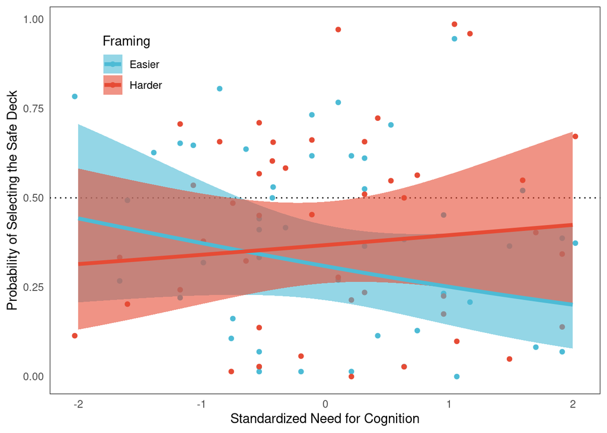

```r
library(jtools)
easyPredCI <- function(model,newdata=NULL,alpha=0.05) {
    ## baseline prediction, on the linear predictor (logit) scale:
    pred0 <- predict(model,re.form=NA,newdata=newdata)
    ## fixed-effects model matrix for new data
    X <- model.matrix(formula(model,fixed.only=TRUE)[-2],newdata)
    beta <- fixef(model) ## fixed-effects coefficients
    V <- vcov(model)     ## variance-covariance matrix of beta
    pred.se <- sqrt(diag(X %*% V %*% t(X))) ## std errors of predictions
    ## inverse-link function
    linkinv <- family(model)$linkinv
    ## construct 95% Normal CIs on the link scale and
    ##  transform back to the response (probability) scale:
    crit <- -qnorm(alpha/2)
    linkinv(cbind(conf.low=pred0-crit*pred.se,
                  conf.high=pred0+crit*pred.se))
}


testdata <- expand.grid(cog_need_c = seq(-2, 2, by = .001), direction_e = c(-.5, .5),
                        performance = 0, trial_c = 0, n_stimuli_lag_c = 0, magnitude_e = 0)

testdata$proba <- predict(mm, newdata = testdata, re.form = NA, type = 'response')
testdata <- cbind(testdata, easyPredCI(mm, newdata = testdata))

preds <- testdata %>%
   # group_by(cog_need_c, direction_e) %>%
   # summarize(proba = mean(proba), conf.low = mean(conf.low), conf.high = mean(conf.high)) %>%
    mutate(direction = ifelse(direction_e == -0.5, 'Easier', 'Harder'))

p3 <- e2 %>%
    group_by(subject, direction) %>%
    summarize(ssd = mean(ssd), cog_need_c = mean(cog_need_c)) %>%
    ggplot(aes(x = cog_need_c, y = ssd)) +
    geom_hline(yintercept = 0.5, linetype = 'dotted') +
    geom_point(aes(color = direction)) +
    geom_ribbon(data = preds,
                aes(x = cog_need_c, ymin = conf.low, ymax = conf.high, fill = direction, y = proba),
                alpha = .6) +
    geom_line(data = preds,
              aes(x = cog_need_c, y = proba, color = direction),
              size = 1.5) +
    labs(
        x = 'Standardized Need for Cognition',
        y = 'Probability of Selecting the Safe Deck',
        color = 'Framing',
        fill = 'Framing'
    ) +
    scale_fill_manual(values = c(`Easier` = npg_blue, `Harder` = npg_red)) +
    scale_color_manual(values = c(`Easier` = npg_blue, `Harder` = npg_red)) +
    theme_bw() +
    theme(axis.ticks = element_blank(),
          panel.grid = element_blank(),
          legend.position = c(.15, .85))
#ggMarginal(p3, fill = pal_npg('nrc')(3)[3], type = 'histogram', binwidth = .10,
          # alpha = 1)
p3
```

[Analysis Homepage](https://davebraun.net/dissertation/experiments/analysis/)

A work by [Dave Braun](https://davebraun.net)

*dab414@lehigh.edu*